# Lecture 601 Unsupervised ML

[figure not shown]

2020-01-15

## Recap @ 601

## Previous lectures

- Introduction to R
- Data types
- Data wrangling
- Reproducibility
- Exploratory analysis
- Univariate analysis
  - Correlation
  - Regression

## This lecture

- Machine Learning
  - Definition
  - Types
- Unsupervised
  - Clustering
- In GIScience
  - Geodemographic classification

## Lecture 601 Machine Learning

## Definition

*“The field of machine learning is concerned with the question of how to construct computer programs that automatically improve with experience.”*

Mitchell, T. (1997). Machine Learning. McGraw Hill.

## Origines

- **Computer Science**:
  - how to manually program computers to solve tasks
- **Statistics**:
  - what conclusions can be inferred from data
- **Machine Learning**:
  - intersection of **computer science** and **statistics**
  - how to get computers to **program themselves** from experience plus some initial structure
  - effective data capture, store, index, retrieve and merge
  - computational tractability

Mitchell, T.M., 2006. The discipline of machine learning (Vol. 9). Pittsburgh, PA: Carnegie Mellon University, School of Computer Science, Machine Learning Department.

## Types of machine learning

Machine learning approaches are divided into two main types

- **Supervised**
  - training of a *“predictive”* model from data
  - one attribute of the dataset is used to “predict” another attribute
  - e.g., classification
- **Unsupervised**
  - discovery of *descriptive* patterns in data
  - commonly used in data mining
  - e.g., clustering

## Supervised

- Training dataset
  - input attribute(s)
  - attribute to predict
- Testing dataset
  - input attribute(s)
  - attribute to predict
- Type of learning model
- Evaluation function
  - evaluates difference between prediction and output in testing data

[figure not shown]

by Josef Steppan  
via Wikimedia Commons,  
CC-BY-SA-4.0

## Unsupervised

- Dataset
  - input attribute(s) to explore
- Type of model for the learning process
  - most approaches are iterative
  - e.g., hierarchical clustering
- Evaluation function
  - evaluates the quality of the pattern under consideration during one iteration

[figure not shown]

by Chire  
via Wikimedia Commons,  
CC-BY-SA-3.0

## … more

- **Semi-supervised learning**
  - between unsupervised and supervised learning
  - combines a small amount of labelled data with a larger un-labelled dataset
  - continuity, cluster, and manifold (lower dimensionality) assumption
- **Reinforcement learning**
  - training agents take actions to maximize reward
  - balancing
    - exploration (new paths/options)
    - exploitation (of current knowledge)

## Neural networks

Supervised learning approach simulating simplistic neurons

- Classic model with 3 sets
  - input neurons
  - output neurons
  - hidden layer
    - combines input values using **weights**
    - **activation function**
- The **traning algorithm** is used to define the best weights

[figure not shown]

by Egm4313.s12 and Glosser.ca  
via Wikimedia Commons,  
CC-BY-SA-3.0

## Deep neural networks

Neural networks with **multiple hidden layers**

The fundamental idea is that *“deeper”* neurons allow for the encoding of more complex characteristics

**Example**: De Sabbata, S. and Liu, P. (2019). [Deep learning geodemographics with autoencoders and geographic convolution](https://www.researchgate.net/publication/334251358_Deep_learning_geodemographics_with_autoencoders_and_geographic_convolution). In proceedings of the 22nd AGILE Conference on Geographic Information Science, Limassol, Cyprus.

[figure not shown]

derived from work by Glosser.ca  
via Wikimedia Commons,  
CC-BY-SA-3.0

## Convolutional neural networks

Deep neural networks with **convolutional hidden layers**

- used very successfully on image object recognition
- convolutional hidden layers *“convolve”* the images
  - a process similar to applying smoothing filters

**Example**: Liu, P. and De Sabbata, S. (2019). [Learning Digital Geographies through a Graph-Based Semi-supervised Approach](https://www.researchgate.net/publication/336021293_Learning_Digital_Geographies_through_a_Graph-Based_Semi-supervised_Approach). In proceedings of the 15th International Conference on GeoComputation, Queenstown, New Zealand.

[figure not shown]

by Aphex34 via Wikimedia Commons, CC-BY-SA-4.0

## Limits

- Complexity
- Training dataset quality
  - garbage in, garbage out
  - e.g., [Facial Recognition Is Accurate, if You’re a White Guy](https://www.nytimes.com/2018/02/09/technology/facial-recognition-race-artificial-intelligence.html) by Steve Lohr (New York Times, Feb. 9, 2018)
- Overfitting
  - creating a model perfect for the training data, but not generic enough to be useful

[figure not shown]

by Chabacano  
ia Wikimedia Commons,  
CC-BY-SA-4.0

## Lecture 601 Clustering

## Clustering task

*"Clustering is an unsupervised machine learning task that automatically divides the data into* *clusters* *, or groups of similar items"*. (Lantz, 2019)

Methods:

- Centroid-based
  - k-means
  - fuzzy c-means
- Hierarchical
- Mixed
  - bootstrap aggregating
- Density-based
  - DBSCAN

## Example

```r
data_to_cluster <- data.frame(
  x_values = c(rnorm(40, 5, 1), rnorm(60, 10, 1), rnorm(20, 12, 3)),
  y_values = c(rnorm(40, 5, 1), rnorm(60, 5, 3), rnorm(20, 15, 1)),
  original_group = c(rep("A", 40), rep("B", 60), rep("C", 20)) )
```

## k-means

k-mean clusters `n` observations in `k` clusters, minimising the within-cluster sum of squares (WCSS)

**Algorithm**: `k` observations a randomly selected as initial centroids, then repeat

- **assignment step**: observations are assigned to the closest centroids
- **update step**: calculate means for each cluster to use as new the centroid

until centroids don’t change anymore, the algorithm has **converged**

```r
kmeans_found_clusters <- data_to_cluster %>%
  select(x_values, y_values) %>%
  kmeans(centers=3, iter.max=50)

data_to_cluster <- data_to_cluster %>%
  add_column(kmeans_cluster = kmeans_found_clusters$cluster)
```

## K-means result

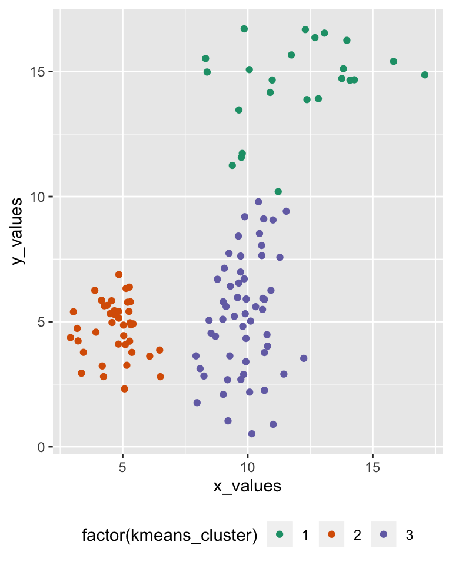

## Fuzzy c-means

Fuzzy c-means is similar to k-means but allows for *"fuzzy*" membership to clusters

Each observation is assigned with a value per each cluster

- usually from `0` to `1`
- indicates how well the observation fits within the cluster
- i.e., based on the distance from the centroid

```r
library(e1071)

cmeans_result <- data_to_cluster %>%
  select(x_values, y_values) %>%
  cmeans(centers=3, iter.max=50)

data_to_cluster <- data_to_cluster %>%
  add_column(c_means_assigned_cluster = cmeans_result$cluster)
```

## Fuzzy c-means

A *“crisp”* classification can be created by picking the highest membership value.

- that also allows to set a membership threshold (e.g., `0.75`)
- leaving some observations without a cluster

```r
data_to_cluster <- data_to_cluster %>%
  add_column(
    c_means_membership = apply(cmeans_result$membership, 1, max)
  ) %>%
  mutate(
    c_means_cluster = ifelse(
      c_means_membership > 0.75,
      c_means_assigned_cluster,
      0
    )
  )
```

## Fuzzy c-means result

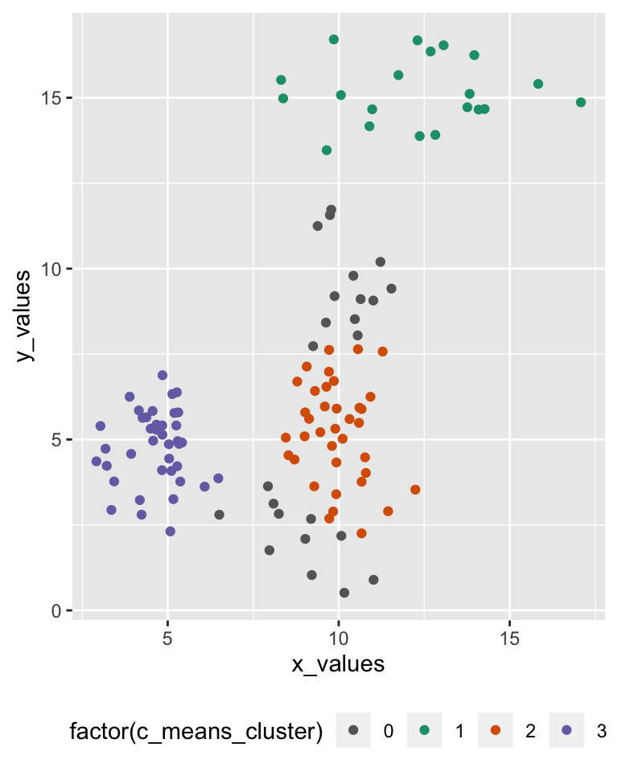

## Hierarchical clustering

**Algorithm**: each object is initialised as, then repeat

- join the two most similar clusters based on a distance-based metric
- e.g., Ward’s (1963) approach is based on variance

until only one single cluster is achieved

```r
hclust_result <- data_to_cluster %>%
  select(x_values, y_values) %>%
  dist(method="euclidean") %>%
  hclust(method="ward.D2")

data_to_cluster <- data_to_cluster %>%
  add_column(hclust_cluster = cutree(hclust_result, k=3))
```

## Clustering tree

This approach generates a clustering tree (dendrogram), which can then be *“cut”* at the desired height

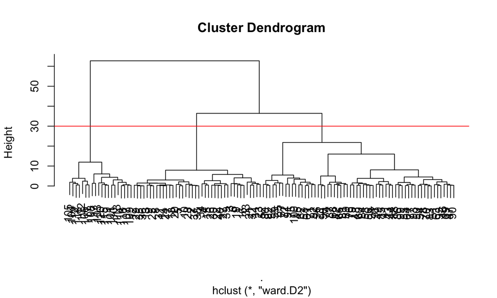

```
## integer(0)
```

```r
plot(hclust_result) + abline(h = 30, col = "red")
```

## Hierarchical clustering result

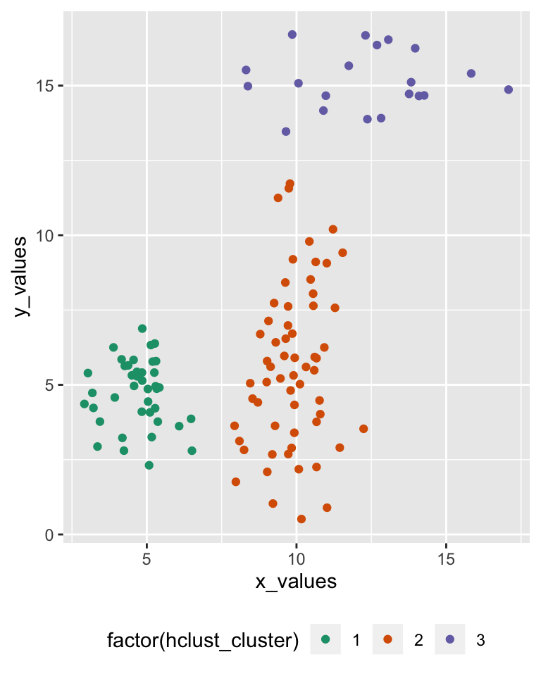

## Bagged clustering

Bootstrap aggregating (*b-agg-ed*) clustering approach (Leisch, 1999)

- first k-means on samples
- then a hierarchical clustering of the centroids generated through the samples

```r
library(e1071)

bclust_result <- data_to_cluster %>%
  select(x_values, y_values) %>%
  bclust(hclust.method="ward.D2", resample = TRUE)

data_to_cluster <- data_to_cluster %>%
  add_column(bclust_cluster = clusters.bclust(bclust_result, 3))
```

## Bagged clustering result

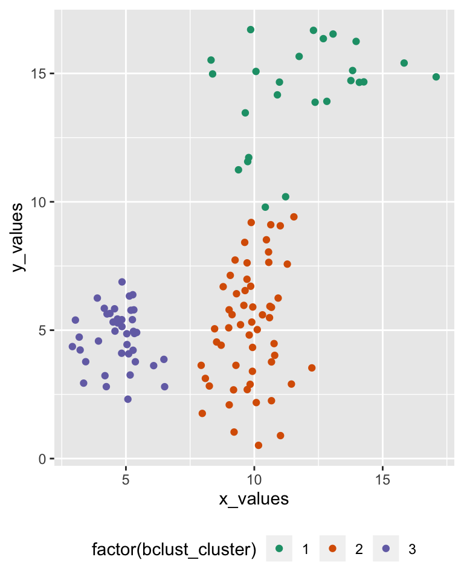

## Density based clustering

DBSCAN (*“density-based spatial clustering of applications with noise”*) starts from an unclustered point and proceeds by aggregating its neighbours to the same cluster, as long as they are within a certain distance. (Ester *et al*, 1996)

```r
library(dbscan)

dbscan_result <- data_to_cluster %>%
  select(x_values, y_values) %>%
   dbscan(eps = 1, minPts = 5)

data_to_cluster <- data_to_cluster %>%
  add_column(dbscan_cluster = dbscan_result$cluster)
```

## DBSCAN result

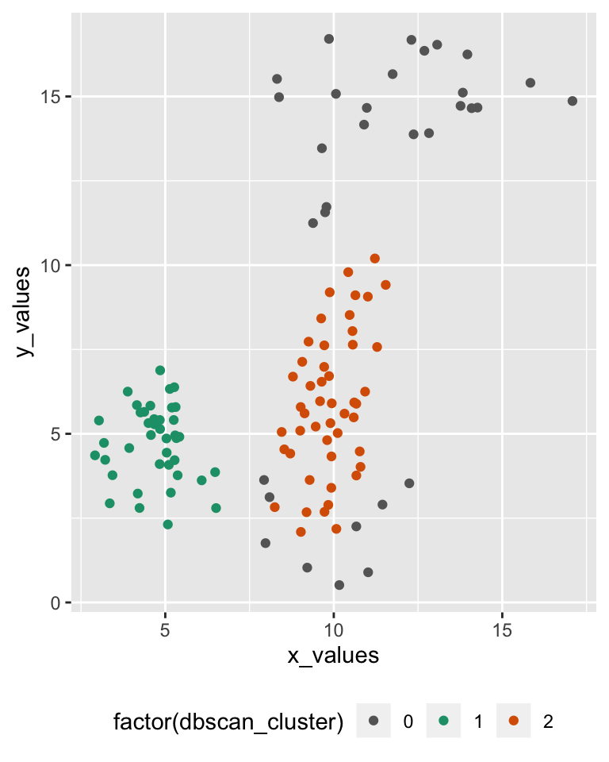

## Geodemographic classifications

In GIScience, the clustering is commonly used to create *geodemographic classifications* such as the 2011 Output Area Classification (Gale *et al.*, 2016)

- initial set of 167 prospective variables from the United Kingdom Census 2011
  - 86 were removed,
  - 41 were retained as they are
  - 40 were combined
  - final set of 60 variables.
- k-means clustering approach to create
  - 8 supergroups
  - 26 groups
  - 76 subgroups.

## Lecture 601 Summary

## Summary

- Machine Learning
  - Definition
  - Types
- Unsupervised
  - Clustering
- In GIScience
  - Geodemographic classification

## Practical session

In the practical session we will see:

Geodemographic classification in R